# Übung: Klassifikation validieren und verbessern

Precision, Recall und die Frage, woran es liegt, wenn das Modell danebenliegt

Simon Munzert, Hertie School

Modul 2, Session 7

# Die Aufgabe

Der Bürgerservice von Musterstadt bekommt Schreiben zu Schlaglöchern, Laternen, Lärm und Müll. Jedes muss zum richtigen Fachamt. In der Fallstudie zu OCR und Sprachmodellen hat das ein Sprachmodell für zehn Schreiben erledigt. Zehn Fälle sagen aber nichts darüber, ob so ein Verfahren im Dauerbetrieb taugt. Dafür braucht es **Validierung**: viele Fälle, von Menschen eingeordnet, und ein ehrlicher Vergleich.

Wir arbeiten mit 560 erfundenen Schreiben (`erzeuge_daten.R`), jedes mit einem Themenbereich als **Goldstandard** und einer Dringlichkeit. Ein Teil der Schreiben liegt bewusst zwischen zwei Bereichen. Wer vorher selbst ein paar Schreiben einordnen möchte: [Interaktive Aufgabe auf der Kurswebseite](https://simonmunzert.com/zertifikat-daten/klassifikation.html). Dort merkt man schnell, dass die Zuordnung nicht immer eindeutig ist. Und was für Menschen schwer ist, ist für Modelle nicht leichter.

**Was Ihr braucht:** R mit `tidyverse`, `tidytext`, `rsample`, `glmnet`, `yardstick`. Der Abschnitt zum Sprachmodell braucht zusätzlich `ellmer` und ein lokal laufendes [Ollama](https://ollama.com); ohne beides wird er übersprungen und zeigt gespeicherte Ergebnisse.

```r
library(tidyverse)
library(tidytext)    # Texte in Wörter zerlegen
library(rsample)     # Trainings- und Testdaten trennen
library(glmnet)      # ein einfaches, schnelles Klassifikationsmodell
library(yardstick)   # Precision, Recall und Co.
library(Matrix)

kategorien <- c("Straßen und Verkehr", "Grünflächen und Spielplätze", "Abfall und Sauberkeit",
                "Beleuchtung", "Lärm", "Sonstiges")
daten <- read_csv("daten/buergerschreiben.csv", show_col_types = FALSE) |>
  mutate(kategorie = factor(kategorie, levels = kategorien))
```

# Schritt 1: Die Daten ansehen

```r
cat(daten$text[1])
```

```
## Hallo zusammen,
##
## Seit drei Wochen fehlt an der Kreuzung Bahnhofstraße 19 das Stoppschild. Es wird von Woche zu Woche schlimmer. Bitte stellen Sie das Schild wieder auf.
##
## Freundliche Grüße
## S. Lehmann
```

```r
count(daten, kategorie, mehrdeutig) |>
  pivot_wider(names_from = mehrdeutig, values_from = n, names_prefix = "mehrdeutig_") |>
  mutate(gesamt = mehrdeutig_FALSE + mehrdeutig_TRUE, anteil = round(gesamt / sum(gesamt), 2)) |>
  knitr::kable()
```

| kategorie | mehrdeutig_FALSE | mehrdeutig_TRUE | gesamt | anteil |
| --- | --- | --- | --- | --- |
| Straßen und Verkehr | 132 | 18 | 150 | 0.27 |
| Grünflächen und Spielplätze | 92 | 13 | 105 | 0.19 |
| Abfall und Sauberkeit | 106 | 14 | 120 | 0.21 |
| Beleuchtung | 62 | 8 | 70 | 0.12 |
| Lärm | 66 | 9 | 75 | 0.13 |
| Sonstiges | 35 | 5 | 40 | 0.07 |

Zwei Dinge fallen auf. Erstens sind die Klassen **ungleich verteilt**: „Straßen und Verkehr“ kommt fast viermal so oft vor wie „Sonstiges“. Zweitens ist jedes achte Schreiben **mehrdeutig**: Baumwurzeln heben den Gehweg an (Straßen oder Grünflächen?), Glasscherben im Sandkasten (Spielplatz oder Sauberkeit?). Der Goldstandard ist in diesen Fällen eine Entscheidung, die man auch anders hätte treffen können.

```r
daten |> filter(mehrdeutig) |> slice(1) |> pull(text) |> cat()
```

```
## Hallo zusammen,
##
## Schon länger wachsen die Sträucher an der Einmündung Wiesenstraße 41 so weit in die Straße, dass man nichts sieht. Bitte schneiden Sie die Sträucher zurück.
##
## Hochachtungsvoll
## H. Haddad
```

```r
daten |> filter(mehrdeutig) |> slice(1) |> select(kategorie, alternative) |> knitr::kable()
```

| kategorie | alternative |
| --- | --- |
| Grünflächen und Spielplätze | Straßen und Verkehr |

**Merke:** Bevor man misst, wie gut ein Modell ist, lohnt der Blick darauf, wie eindeutig die Aufgabe überhaupt ist. Wo sich zwei Sachbearbeitende nicht einig wären, kann auch ein Modell nicht „richtig“ liegen.

# Schritt 2: Trainings- und Testdaten trennen

Ein Modell, das an denselben Schreiben geprüft wird, aus denen es gelernt hat, sieht immer gut aus. Deshalb legen wir ein Fünftel der Daten beiseite, bevor irgendetwas trainiert wird. `strata` sorgt dafür, dass die seltenen Klassen in beiden Teilen vertreten sind.

```r
set.seed(2026)
aufteilung <- initial_split(daten, prop = 0.8, strata = kategorie)
train <- training(aufteilung)
test  <- testing(aufteilung)
c(training = nrow(train), test = nrow(test))
```

```
## training     test
##      447      113
```

# Schritt 3: Ein einfaches Modell

Wir zählen, welche Wörter in einem Schreiben vorkommen, und lassen eine regularisierte logistische Regression lernen, welche Wörter für welchen Bereich sprechen („Leuchtmittel“ für Beleuchtung, „Tonne“ für Abfall). Wir nehmen bewusst ein so einfaches Verfahren: Es ist in Sekunden trainiert, und man kann hineinschauen.

```r
tokenisiere <- function(df) {
  df |> select(id, text) |> unnest_tokens(wort, text) |> filter(!str_detect(wort, "^[0-9]+$"))
}

# Dokument-Wort-Matrix mit festem Vokabular (damit Test- und Trainingsdaten dieselben Spalten haben)
baue_matrix <- function(df, vokabular) {
  tok <- tokenisiere(df) |> filter(wort %in% vokabular) |> count(id, wort)
  m <- cast_sparse(tok, id, wort, n)
  fehlt_w <- setdiff(vokabular, colnames(m))
  if (length(fehlt_w)) m <- cbind(m, Matrix(0, nrow(m), length(fehlt_w), sparse = TRUE, dimnames = list(rownames(m), fehlt_w)))
  fehlt_id <- setdiff(df$id, rownames(m))
  if (length(fehlt_id)) m <- rbind(m, Matrix(0, length(fehlt_id), ncol(m), sparse = TRUE, dimnames = list(fehlt_id, colnames(m))))
  m[df$id, vokabular, drop = FALSE]
}

trainiere <- function(train, min_haeufigkeit = 3) {
  vokabular <- tokenisiere(train) |> count(wort) |> filter(n >= min_haeufigkeit) |> pull(wort)
  X <- baue_matrix(train, vokabular)
  # Folds geschichtet nach Klasse, damit auch seltene Klassen in jedem Fold vorkommen
  foldid <- as.integer(ave(seq_len(nrow(train)), train$kategorie, FUN = \(i) sample(rep(1:5, length.out = length(i)))))
  fit <- cv.glmnet(X, train$kategorie, family = "multinomial", alpha = 0, foldid = foldid)
  list(fit = fit, vokabular = vokabular)
}

vorhersage <- function(modell, df) {
  X <- baue_matrix(df, modell$vokabular)
  p <- predict(modell$fit, X, s = "lambda.min", type = "response")[, , 1]
  df |> mutate(vorhersage = factor(colnames(p)[max.col(p)], levels = kategorien),
               sicherheit = apply(p, 1, max))
}
```

```r
modell <- trainiere(train)
length(modell$vokabular)   # so viele Wörter kennt das Modell
```

```
## [1] 536
```

```r
ergebnis <- vorhersage(modell, test)
```

Welche Wörter sprechen für „Beleuchtung“? Die größten Koeffizienten verraten es:

```r
koef <- coef(modell$fit, s = "lambda.min")$Beleuchtung
tibble(wort = rownames(koef), gewicht = as.numeric(koef)) |>
  filter(wort != "(Intercept)") |> slice_max(gewicht, n = 8) |> knitr::kable(digits = 2)
```

| wort | gewicht |
| --- | --- |
| weihnachtsbeleuchtung | 0.28 |
| schalten | 0.28 |
| februar | 0.28 |
| zeitschaltung | 0.27 |
| straßenbeleuchtung | 0.27 |
| brennt | 0.27 |
| leuchtmittel | 0.26 |
| flackert | 0.26 |

# Schritt 4: Bewerten mit Precision und Recall

Die **Konfusionsmatrix** zeigt, was das Modell aus jedem echten Bereich gemacht hat (Zeilen: Vorhersage, Spalten: Goldstandard).

```r
conf_mat(ergebnis, truth = kategorie, estimate = vorhersage)
```

```
##                              Truth
## Prediction                    Straßen und Verkehr Grünflächen und Spielplätze Abfall und Sauberkeit
##   Straßen und Verkehr                          29                           0                     0
##   Grünflächen und Spielplätze                   0                          21                     0
##   Abfall und Sauberkeit                         0                           0                    25
##   Beleuchtung                                   0                           0                     0
##   Lärm                                          0                           0                     0
##   Sonstiges                                     0                           0                     0
##                              Truth
## Prediction                    Beleuchtung Lärm Sonstiges
##   Straßen und Verkehr                   0    2         3
##   Grünflächen und Spielplätze           0    0         1
##   Abfall und Sauberkeit                 0    0         0
##   Beleuchtung                          12    0         0
##   Lärm                                  0   13         0
##   Sonstiges                             0    0         7
```

```r
# Kennzahlen je Klasse: Precision = Anteil richtiger unter den Vorhersagen dieser Klasse,
# Recall = Anteil gefundener unter den echten Fällen dieser Klasse, F1 = harmonisches Mittel
je_klasse <- function(df) {
  map_dfr(kategorien, function(k) {
    tp <- sum(df$vorhersage == k & df$kategorie == k)
    tibble(kategorie = k, n = sum(df$kategorie == k),
           precision = tp / max(sum(df$vorhersage == k), 1),
           recall    = tp / max(sum(df$kategorie == k), 1)) |>
      mutate(f1 = if_else(precision + recall > 0, 2 * precision * recall / (precision + recall), 0))
  })
}
gesamt <- function(df) tibble(accuracy = mean(df$vorhersage == df$kategorie),
                              f1_makro = mean(je_klasse(df)$f1))
```

```r
gesamt(ergebnis) |> knitr::kable(digits = 3)
```

| accuracy | f1_makro |
| --- | --- |
| 0.947 | 0.934 |

```r
je_klasse(ergebnis) |> knitr::kable(digits = 2)
```

| kategorie | n | precision | recall | f1 |
| --- | --- | --- | --- | --- |
| Straßen und Verkehr | 29 | 0.85 | 1.00 | 0.92 |
| Grünflächen und Spielplätze | 21 | 0.95 | 1.00 | 0.98 |
| Abfall und Sauberkeit | 25 | 1.00 | 1.00 | 1.00 |
| Beleuchtung | 12 | 1.00 | 1.00 | 1.00 |
| Lärm | 15 | 1.00 | 0.87 | 0.93 |
| Sonstiges | 11 | 1.00 | 0.64 | 0.78 |

Lesebeispiel: Von allen Schreiben, die das Modell „Sonstiges“ nennt, ist der Precision-Anteil tatsächlich „Sonstiges“. Von allen echten „Sonstiges“-Schreiben findet es den Recall-Anteil. Die Gesamttrefferquote (Accuracy) ist hoch, weil die großen Klassen gut laufen. Die kleine Klasse trägt wenig zur Accuracy bei, und genau dort ist das Modell am schwächsten.

Wo liegen die Fehler? An zwei Stellen: bei der kleinen Klasse „Sonstiges“, für die das Modell wenig Beispiele hatte, und bei den mehrdeutigen Schreiben:

```r
ergebnis |>
  mutate(richtig = vorhersage == kategorie,
         vertretbar = richtig | (!is.na(alternative) & vorhersage == alternative)) |>
  group_by(mehrdeutig) |>
  summarize(n = n(), trefferquote = mean(richtig), vertretbar = mean(vertretbar)) |>
  knitr::kable(digits = 2)
```

| mehrdeutig | n | trefferquote | vertretbar |
| --- | --- | --- | --- |
| FALSE | 99 | 0.96 | 0.96 |
| TRUE | 14 | 0.86 | 1.00 |

Zählt man bei den mehrdeutigen Schreiben die „Alternative“ als ebenfalls richtig, verschwinden ihre Fehler vollständig. Die Frage, wie gut das Modell ist, hängt also auch davon ab, wie streng der Goldstandard ist.

**Merke:** Accuracy allein täuscht bei ungleichen Klassen. Precision und Recall je Klasse zeigen, *wo* es hakt. Und ein Blick auf die Fehlerfälle zeigt, *warum*: Oft liegt es an der unscharfen Aufgabe, bevor es am Modell liegt.

# Schritt 5: Der Daten-Input entscheidet

Dasselbe Modell, andere Daten. Drei Experimente zeigen, wie stark die Leistung vom Input abhängt.

## OCR-Fehler im Text

In der Praxis kommen die Texte aus Scans. Wir simulieren OCR-Fehler, indem wir einen Teil der Buchstaben durch typische Verwechsler ersetzen (e→c, l→1, o→0, ä→a …).

```r
verrausche <- function(text, rate) {
  ersatz <- c(e = "c", l = "1", o = "0", i = "l", u = "v", n = "h", "ä" = "a", "ö" = "o", "ü" = "u", "ß" = "B", s = "5", t = "f")
  map_chr(text, function(t) {
    z <- str_split(t, "")[[1]]
    treffer <- which(z %in% names(ersatz) & runif(length(z)) < rate)
    z[treffer] <- ersatz[z[treffer]]
    paste(z, collapse = "")
  })
}
set.seed(1)
cat(verrausche(test$text[1], 0.15))
```

```
## Hallo zusammen,
##
## Seit drei Wochen feh1t an der Kreuzung Bahnhofstraßc 19 das Stoppschild. E5 wird von Wochc zu Wochc 5chlimmer. Bitfc stellen Sie da5 Schild wieder auf.
##
## Freundliche Grüße
## S. Lchmahn
```

```r
set.seed(1)
ocr_experiment <- map_dfr(c(0, 0.05, 0.10, 0.20, 0.30), function(rate) {
  test_verrauscht <- test |> mutate(text = verrausche(text, rate))
  vorhersage(modell, test_verrauscht) |> gesamt() |> mutate(fehlerrate = rate, .before = 1)
})
knitr::kable(ocr_experiment, digits = 3)
```

| fehlerrate | accuracy | f1_makro |
| --- | --- | --- |
| 0.00 | 0.947 | 0.934 |
| 0.05 | 0.929 | 0.910 |
| 0.10 | 0.858 | 0.808 |
| 0.20 | 0.779 | 0.713 |
| 0.30 | 0.699 | 0.645 |

Mit jedem zehnten falschen Buchstaben bricht die Trefferquote spürbar ein. Das Modell kennt das Wort „Laterne“; mit „Latcrnc“ kann es nichts anfangen. Darum lohnt sich die OCR-Vorverarbeitung aus der Fallstudie, und darum kann es sich lohnen, das Modell auch mit verrauschten Texten zu trainieren.

## Falsche Labels im Training

Jetzt sind die Texte sauber, aber ein Teil der Trainingslabels ist falsch, etwa weil beim Kodieren geschlampt wurde oder mehrere Personen unterschiedlich kodiert haben.

```r
set.seed(2)
label_experiment <- map_dfr(c(0, 0.10, 0.20, 0.30, 0.40), function(rate) {
  train_verrauscht <- train |>
    mutate(kategorie = if_else(runif(n()) < rate,
                               factor(map_chr(kategorie, ~ sample(setdiff(kategorien, .x), 1)), levels = kategorien),
                               kategorie))
  vorhersage(trainiere(train_verrauscht), test) |> gesamt() |> mutate(anteil_falsche_labels = rate, .before = 1)
})
knitr::kable(label_experiment, digits = 3)
```

| anteil_falsche_labels | accuracy | f1_makro |
| --- | --- | --- |
| 0.0 | 0.947 | 0.934 |
| 0.1 | 0.947 | 0.935 |
| 0.2 | 0.956 | 0.944 |
| 0.3 | 0.920 | 0.906 |
| 0.4 | 0.885 | 0.866 |

Das Modell ist gegen einzelne falsche Labels erstaunlich robust. Werden es viele, lernt es den Fehler mit. Wichtiger als dieser Durchschnitt ist aber: Sind die falschen Labels systematisch (eine Person ordnet Spielplatzmüll immer der Sauberkeit zu), übernimmt das Modell genau diese Regel.

## Zu wenige Beispiele

```r
set.seed(3)
# geschichtet ziehen, damit auch bei kleinen Stichproben jede Klasse vertreten ist
lernkurve <- map_dfr(c(60, 100, 160, 240, 320, nrow(train)), function(n) {
  teil <- train |> group_by(kategorie) |> slice_sample(prop = n / nrow(train)) |> ungroup()
  vorhersage(trainiere(teil), test) |> gesamt() |> mutate(trainingsfaelle = n, .before = 1)
})
knitr::kable(lernkurve, digits = 3)
```

| trainingsfaelle | accuracy | f1_makro |
| --- | --- | --- |
| 60 | 0.487 | 0.362 |
| 100 | 0.619 | 0.576 |
| 160 | 0.735 | 0.685 |
| 240 | 0.779 | 0.712 |
| 320 | 0.876 | 0.853 |
| 447 | 0.947 | 0.934 |

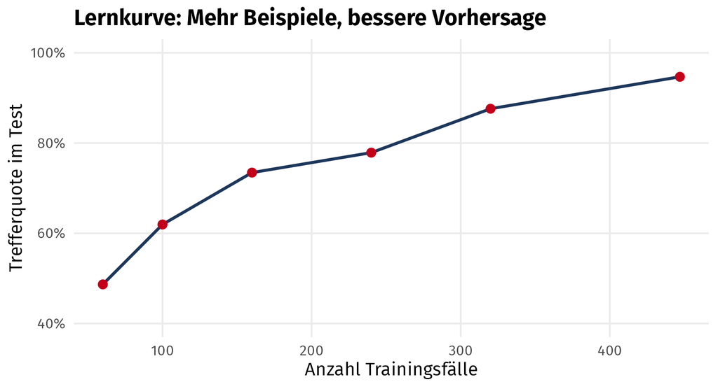

```r
ggplot(lernkurve, aes(trainingsfaelle, accuracy)) +
  geom_line(colour = "#1D375B", linewidth = 1) + geom_point(colour = "#C2001A", size = 2.5) +
  scale_y_continuous(labels = scales::percent, limits = c(0.4, 1)) +
  labs(x = "Anzahl Trainingsfälle", y = "Trefferquote im Test", title = "Lernkurve: Mehr Beispiele, bessere Vorhersage") +
  theme_minimal(base_family = "Fira Sans", base_size = 13) +
  theme(plot.title = element_text(face = "bold"), panel.grid.minor = element_blank())
```

**Merke:** „Das Modell ist zu 85 % genau“ beschreibt immer das Zusammenspiel von Modell *und* Daten: Textqualität, Labelqualität, Menge und Verteilung. Ändert sich der Input, gilt die Zahl nicht mehr.

# Schritt 6: Validierung, die hält

## Ein Split ist eine Stichprobe

Unsere Trefferquote stammt aus **einem** zufälligen Test-Set mit gut hundert Schreiben. Ein anderer Zufall, eine andere Zahl:

```r
set.seed(4)
wiederholungen <- map_dbl(1:10, function(i) {
  s <- initial_split(daten, prop = 0.8, strata = kategorie)
  vorhersage(trainiere(training(s)), testing(s)) |> gesamt() |> pull(accuracy)
})
round(range(wiederholungen), 3)
```

```
## [1] 0.930 0.991
```

Zwischen bestem und schlechtestem Split liegen mehrere Prozentpunkte. Wer zwei Verfahren vergleicht, die sich um zwei Punkte unterscheiden, vergleicht womöglich nur Zufall.

## Kreuzvalidierung

Die **k-fache Kreuzvalidierung** teilt die Daten in k Teile, trainiert k-mal auf k−1 Teilen und testet auf dem übrigen. Jedes Schreiben wird genau einmal getestet, und man bekommt eine Schätzung mit Streuung statt einer einzelnen Zahl.

```r
set.seed(5)
folds <- vfold_cv(daten, v = 5, strata = kategorie)
cv <- map_dfr(folds$splits, function(s) {
  vorhersage(trainiere(analysis(s)), assessment(s)) |> gesamt()
}, .id = "fold")
knitr::kable(cv, digits = 3)
```

| fold | accuracy | f1_makro |
| --- | --- | --- |
| 1 | 0.956 | 0.943 |
| 2 | 0.973 | 0.962 |
| 3 | 0.955 | 0.945 |
| 4 | 0.937 | 0.930 |
| 5 | 0.982 | 0.976 |

```r
cv |> summarize(mittel = mean(accuracy), streuung = sd(accuracy)) |> knitr::kable(digits = 3)
```

| mittel | streuung |
| --- | --- |
| 0.961 | 0.017 |

## Datenlecks

Unsere Schreiben entstehen aus Bausteinen; viele Formulierungen tauchen in Training und Test fast identisch auf. Das Modell lernt dadurch leichter, als es bei echten Schreiben wäre, und die Zahlen oben sind eher zu optimistisch. In der Praxis passiert dasselbe, wenn Vorlagen, Serienbriefe oder Dubletten in beide Hälften geraten, oder wenn die Testdaten aus derselben Woche stammen wie die Trainingsdaten und im Winter dann andere Anliegen kommen. Eine saubere Validierung prüft an Daten, die das Modell im Betrieb wirklich sehen würde: aus einem späteren Zeitraum, aus einem anderen Stadtteil, ohne Dubletten.

**Merke:** Eine einzelne Trefferquote ist eine Stichprobe. Kreuzvalidierung gibt eine Spanne. Und beides ist nur so viel wert, wie die Testdaten dem Betrieb ähneln.

# Schritt 7: Besser werden

Was hilft, wenn die Zahlen zu schwach sind? Ein größeres Modell steht auf dieser Liste ganz unten.

## Unsichere Fälle an Menschen geben

Das Modell liefert zu jeder Vorhersage eine Wahrscheinlichkeit. Übernimmt man nur die sicheren Fälle automatisch und legt den Rest einem Menschen vor, steigt die Precision der automatischen Zuordnung. Der Preis ist weniger Automatisierung:

```r
map_dfr(c(0, 0.5, 0.6, 0.7, 0.8, 0.9), function(s) {
  auto <- ergebnis |> filter(sicherheit >= s)
  tibble(schwelle = s, anteil_automatisch = nrow(auto) / nrow(ergebnis),
         trefferquote_automatisch = mean(auto$vorhersage == auto$kategorie))
}) |> knitr::kable(digits = 2)
```

| schwelle | anteil_automatisch | trefferquote_automatisch |
| --- | --- | --- |
| 0.0 | 1.00 | 0.95 |
| 0.5 | 0.54 | 1.00 |
| 0.6 | 0.18 | 1.00 |
| 0.7 | 0.00 | NaN |
| 0.8 | 0.00 | NaN |
| 0.9 | 0.00 | NaN |

Diese Tabelle ist die eigentliche Entscheidungsgrundlage für eine Behörde: Wie viel Handarbeit ist uns welche Fehlerquote wert?

## Den Goldstandard schärfen

Ein Teil der Fehler lag bei den mehrdeutigen Schreiben. Zwei Wege: Entweder die Kodierregeln so präzisieren, dass die Zuordnung eindeutig wird („Schäden am Gehweg gehören immer zu Straßen, egal was die Ursache ist“), oder eine Klasse „Mehrere Bereiche“ einführen, die zur Nachprüfung geht. Beides ist Arbeit an den Daten; das Modell bleibt, wie es ist.

## Mehr und bessere Daten

Die Lernkurve zeigt, ob mehr Beispiele helfen. Noch mehr bringt es oft, die **seltenen Klassen** gezielt nachzukodieren: Für „Sonstiges“ hatte das Modell nur rund 30 Trainingsfälle.

## Ein anderes Modell: Sprachmodell ohne Training

Ein Sprachmodell kommt ohne Trainingsdaten aus; es braucht lediglich die Liste der Kategorien. Wie schlägt es sich auf denselben Testfällen? Der Vergleich läuft mit einem lokalen Modell über Ollama und wird zwischengespeichert (`daten/llm_vergleich.csv`).

```r
llm_datei <- "daten/llm_vergleich.csv"
ollama_da <- tryCatch({ httr2::request("http://localhost:11434") |> httr2::req_timeout(2) |> httr2::req_perform(); TRUE },
                      error = function(e) FALSE)
llm_laeuft <- ollama_da || file.exists(llm_datei)
```

```r
library(ellmer)
set.seed(6)
stichprobe <- ergebnis |> slice_sample(n = 40)

if (file.exists(llm_datei)) {
  llm <- read_csv(llm_datei, show_col_types = FALSE)
} else {
  modelle <- httr2::request("http://localhost:11434/api/tags") |> httr2::req_perform() |> httr2::resp_body_json() |>
    pluck("models") |> map_chr("name")
  chat <- chat_ollama(model = modelle[1], echo = "none",
                      system_prompt = "Du ordnest Bürgerschreiben an eine Stadtverwaltung dem zuständigen Themenbereich zu.")
  typ <- type_object(kategorie = type_enum(kategorien, "Zuständiger Themenbereich"))
  # Die Kategorien stehen mit kurzer Erklärung im Prompt; nur die Liste im Antwortschema reicht lokalen Modellen nicht
  anweisung <- paste0("Ordne dieses Schreiben genau einem Themenbereich zu. Erlaubte Themenbereiche:\n",
    "- Straßen und Verkehr: Fahrbahn, Gehweg, Schilder, Ampeln, Parken, Tempo\n",
    "- Grünflächen und Spielplätze: Bäume, Hecken, Parks, Spielgeräte\n",
    "- Abfall und Sauberkeit: Tonnen, Müll, Container, Verschmutzung\n",
    "- Beleuchtung: Straßenlaternen und andere öffentliche Beleuchtung\n",
    "- Lärm: Ruhestörung durch Gaststätten, Baustellen, Anlagen, Personen\n",
    "- Sonstiges: Lob, Beschwerden über die Verwaltung selbst, Anträge, Formulare, alles andere\n",
    "Gib den Themenbereich wörtlich so an, wie er in der Liste steht.\n\n--- SCHREIBEN ---\n")
  antworten <- parallel_chat_structured(chat, map(stichprobe$text, ~ paste0(anweisung, .x)), type = typ, max_active = 1)
  llm <- stichprobe |> select(id) |> mutate(llm = as_tibble(antworten)$kategorie)
  write_csv(llm, llm_datei)
}

vergleich <- stichprobe |> inner_join(llm, by = "id") |>
  mutate(llm = factor(llm, levels = kategorien))
tibble(verfahren = c("Wortzähl-Modell (trainiert)", "Sprachmodell (ohne Training)"),
       trefferquote = c(mean(vergleich$vorhersage == vergleich$kategorie), mean(vergleich$llm == vergleich$kategorie)),
       vertretbar = c(mean(vergleich$vorhersage == vergleich$kategorie | (!is.na(vergleich$alternative) & vergleich$vorhersage == vergleich$alternative)),
                      mean(vergleich$llm == vergleich$kategorie | (!is.na(vergleich$alternative) & vergleich$llm == vergleich$alternative)))) |>
  knitr::kable(digits = 2)
```

| verfahren | trefferquote | vertretbar |
| --- | --- | --- |
| Wortzähl-Modell (trainiert) | 0.95 | 0.95 |
| Sprachmodell (ohne Training) | 0.92 | 0.92 |

# Was wir mitnehmen

- **Erst die Aufgabe prüfen, dann das Modell.** Wo Menschen uneins sind, gibt es kein „richtig“, das ein Modell treffen könnte.
- **Precision und Recall je Klasse** ergänzen die Accuracy. Die seltenen Klassen sind oft die wichtigen.
- **Die Zahl gehört zu den Daten.** OCR-Fehler, falsche Labels, zu wenige Beispiele: Jedes davon verschiebt das Ergebnis, ohne dass sich am Modell etwas ändert.
- **Validieren wie im Betrieb.** Kreuzvalidierung statt eines Splits; Testdaten, die dem echten Einsatz ähneln; Dubletten raus.
- **Verbessern heißt meist: an den Daten arbeiten.** Kodierregeln schärfen, seltene Klassen nachkodieren, unsichere Fälle an Menschen geben.

**Zum Weiterspielen:** Trainiert das Modell mit verrauschten Texten (`verrausche(train$text, 0.1)`) und testet es auf verrauschten Texten. Wird es robuster? Oder ändert die Kodierregel: Weist alle mehrdeutigen Schreiben ihrer Alternative zu und schaut, ob die Fehler wandern oder verschwinden.